# Class 6/Lab1: Classification with Support Vector Machines (SVMs)

Week 6 (10.03)

## Introduction

In this lab, we will:

1. Load and explore the `iris` dataset.
2. Visualize the data to understand the relationships between variables.
3. Split the data into training and testing sets.
4. Train three different types of SVM models: **linear**, **polynomial**, and **radial basis function (RBF)**.
5. Evaluate and compare the performance of these models on the test data.

```r
# Clear environment and unload packages
rm(list = ls())
# The following line might show a note if no packages were loaded, which is normal.
pacman::p_unload(pacman::p_loaded())

# Load necessary packages
pacman::p_load(tidyverse, e1071, caret, ggsci, patchwork)
```

### Examine the Data

The `iris` dataset is a classic dataset in machine learning and is built into R. It contains measurements for 150 iris flowers from three different species: **setosa**, **versicolor**, and **virginica**.

Let’s load the data and inspect it using `head()`, `summary()`, and `str()`.

- `head()`: Shows the first few rows of the data.
- `summary()`: Provides descriptive statistics for each variable, such as mean, median, and quartiles.
- `str()`: Displays the structure of the data, including the data type of each variable and the number of observations.

```r
# Load the iris dataset
data(iris)

# Display the first 6 rows
head(iris)
```

```
##   Sepal.Length Sepal.Width Petal.Length Petal.Width Species
## 1          5.1         3.5          1.4         0.2  setosa
## 2          4.9         3.0          1.4         0.2  setosa
## 3          4.7         3.2          1.3         0.2  setosa
## 4          4.6         3.1          1.5         0.2  setosa
## 5          5.0         3.6          1.4         0.2  setosa
## 6          5.4         3.9          1.7         0.4  setosa
```

```r
# Get a statistical summary
summary(iris)
```

```
##   Sepal.Length    Sepal.Width     Petal.Length    Petal.Width
##  Min.   :4.300   Min.   :2.000   Min.   :1.000   Min.   :0.100
##  1st Qu.:5.100   1st Qu.:2.800   1st Qu.:1.600   1st Qu.:0.300
##  Median :5.800   Median :3.000   Median :4.350   Median :1.300
##  Mean   :5.843   Mean   :3.057   Mean   :3.758   Mean   :1.199
##  3rd Qu.:6.400   3rd Qu.:3.300   3rd Qu.:5.100   3rd Qu.:1.800
##  Max.   :7.900   Max.   :4.400   Max.   :6.900   Max.   :2.500
##        Species
##  setosa    :50
##  versicolor:50
##  virginica :50
##
##
##
```

```r
# Examine the structure of the dataframe
str(iris)
```

```
## 'data.frame':    150 obs. of  5 variables:
##  $ Sepal.Length: num  5.1 4.9 4.7 4.6 5 5.4 4.6 5 4.4 4.9 ...
##  $ Sepal.Width : num  3.5 3 3.2 3.1 3.6 3.9 3.4 3.4 2.9 3.1 ...
##  $ Petal.Length: num  1.4 1.4 1.3 1.5 1.4 1.7 1.4 1.5 1.4 1.5 ...
##  $ Petal.Width : num  0.2 0.2 0.2 0.2 0.2 0.4 0.3 0.2 0.2 0.1 ...
##  $ Species     : Factor w/ 3 levels "setosa","versicolor",..: 1 1 1 1 1 1 1 1 1 1 ...
```

**Interpretation of the Data:** From the output, we can see the dataset has 150 observations and 5 variables. The variables are `Sepal.Length`, `Sepal.Width`, `Petal.Length`, and `Petal.Width`, which are all numeric (`num`), and `Species`, which is a categorical variable (`Factor`) with 3 levels. There are 50 samples for each of the three species.

### Visualization

Visualizing the data is a crucial step to understand the separability of the classes. We create two scatter plots: one for sepal dimensions and one for petal dimensions. We color the points by `Species` to see how distinct the groups are.

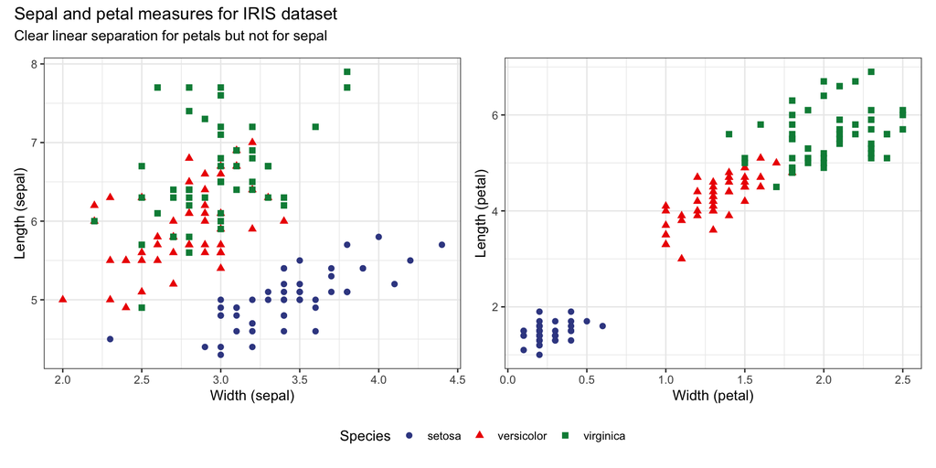

```r
(iris |>
  ggplot(aes(x = Sepal.Width, y = Sepal.Length, color = Species, shape = Species)) +
  geom_point(size = 2) +
  theme_bw() +
  scale_color_aaas() +
  theme(legend.position = "bottom") +
  labs(x = "Width (sepal)", y = "Length (sepal)")) +
(iris |>
   ggplot(aes(x = Petal.Width, y = Petal.Length, color = Species, shape = Species)) +
   geom_point(size = 2) +
   theme_bw() +
   scale_color_aaas() +
   theme(legend.position = "bottom") +
   labs(x = "Width (petal)", y = "Length (petal)")) +
  plot_layout(guides = "collect") +
  plot_annotation(
    title = 'Sepal and petal measures for IRIS dataset',
    subtitle = 'Clear linear separation for petals but not for sepal'
  )  &
  theme(legend.position = "bottom")
```

**Plot Interpretation:** As noted in the plot’s subtitle, the species are much more clearly separated when we plot them by their **petal dimensions**. The sepal dimensions show significant overlap, especially between the versicolor and virginica species. For this lab, we will intentionally use the more challenging sepal features to see how well SVM can perform.

### Training and Testing Splits

To evaluate our model’s performance on unseen data, we must split our dataset into a **training set** (used to build the model) and a **testing set** (used to evaluate it). We’ll use an 80/20 split, meaning 80% of the data will be used for training and 20% for testing.

We use the `createDataPartition` function from the `caret` package to create a stratified split, which ensures that the proportion of each species is the same in both the training and testing sets.

**Note:** For this analysis, we are only using `Sepal.Length` and `Sepal.Width` as our predictors (`train_x`, `test_x`).

```r
# Set a seed for reproducibility
set.seed(42)

# Create indices for the 80% training data
train_indices <- createDataPartition(iris$Species, p = 0.8, list = FALSE)

# Create the training feature set (X) and target (y)
train_x <- as.matrix(iris |> dplyr::select(-Species))[train_indices, c("Sepal.Length", "Sepal.Width")]
train_y <- as.matrix(iris |> dplyr::select(Species))[train_indices, ]

# Create the testing feature set (X) and target (y)
test_x <- as.matrix(iris |> dplyr::select(-Species))[-train_indices, c("Sepal.Length", "Sepal.Width")]
test_y <- (iris |> dplyr::select(Species))[-train_indices, ]
```

### Fitting SVMs

Now we’ll train three SVM models with different kernels. We use the `train` function from `caret`, which helps automate hyperparameter tuning using cross-validation. We’ll use 10-fold repeated cross-validation to get a robust estimate of model performance. We also pre-process the data by centering and scaling it, which is standard practice for SVMs.

```r
# Define the training control method
train_control <- trainControl(method="repeatedcv", number=10)

## Train a Linear SVM
# We tune the cost parameter 'C'
svm_linear <- train(x = train_x, y = train_y,
                    method = "svmLinear",
                    trControl = train_control,
                    preProcess = c("center","scale"),
                    tuneGrid = expand.grid(C = c(1/16, 1/8, 1/4, 1/2, 1, 2, 4)))

## Train a Polynomial SVM
# We tune 'degree', 'scale', and 'C'
svm_poly <- train(x = train_x, y = train_y,
                  method = "svmPoly",
                  trControl = train_control,
                  preProcess = c("center","scale"),
                  tuneGrid = expand.grid(degree = c(1:4),
                                         scale = c(0.001, 0.010, 0.1, 1),
                                         C = c(1/16, 1/8, 1/4, 1/2, 1, 2, 4)))

## Train a Radial Basis Function (RBF) SVM
# We tune 'sigma' and 'C'
svm_radial <- train(x = train_x, y = train_y,
                    method = "svmRadial",
                    trControl = train_control,
                    preProcess = c("center","scale"),
                    tuneGrid = expand.grid(sigma = c(0.001, 0.010, 0.1, 1),
                                           C = c(1/16, 1/8, 1/4, 1/2, 1, 2, 4)))
```

### Model Performance

After training, we evaluate each model on the held-out test set (`test_x` and `test_y`). A **confusion matrix** is an excellent tool for this, as it shows us exactly where the model made correct and incorrect predictions for each class.

#### SVM with Linear Kernel

```r
# Note: The output below is from the provided temp.txt file.
confusionMatrix(data = predict(svm_linear, newdata = test_x), reference = test_y)
```

```
## Confusion Matrix and Statistics
##
##             Reference
## Prediction   setosa versicolor virginica
##   setosa          9          0         0
##   versicolor      1          8         6
##   virginica       0          2         4
##
## Overall Statistics
##
##                Accuracy : 0.7
##                  95% CI : (0.506, 0.8527)
##     No Information Rate : 0.3333
##     P-Value [Acc > NIR] : 4.433e-05
##
##                   Kappa : 0.55
##
##  Mcnemar's Test P-Value : NA
##
## Statistics by Class:
##
##                      Class: setosa Class: versicolor Class: virginica
## Sensitivity                 0.9000            0.8000           0.4000
## Specificity                 1.0000            0.6500           0.9000
## Pos Pred Value              1.0000            0.5333           0.6667
## Neg Pred Value              0.9524            0.8667           0.7500
## Prevalence                  0.3333            0.3333           0.3333
## Detection Rate              0.3000            0.2667           0.1333
## Detection Prevalence        0.3000            0.5000           0.2000
## Balanced Accuracy           0.9500            0.7250           0.6500
```

**Interpretation:** The linear SVM achieved an overall **accuracy of 70%**.

#### SVM with Radial (RBF) Kernel

```r
# Note: The output below is from the provided temp.txt file.
confusionMatrix(data = predict(svm_radial, newdata = test_x), reference = test_y)
```

```
## Confusion Matrix and Statistics
##
##             Reference
## Prediction   setosa versicolor virginica
##   setosa          9          0         0
##   versicolor      1          7         4
##   virginica       0          3         6
##
## Overall Statistics
##
##                Accuracy : 0.7333
##                  95% CI : (0.5411, 0.8772)
##     No Information Rate : 0.3333
##     P-Value [Acc > NIR] : 8.752e-06
##
##                   Kappa : 0.6
##
##  Mcnemar's Test P-Value : NA
##
## Statistics by Class:
##
##                      Class: setosa Class: versicolor Class: virginica
## Sensitivity                 0.9000            0.7000           0.6000
## Specificity                 1.0000            0.7500           0.8500
## Pos Pred Value              1.0000            0.5833           0.6667
## Neg Pred Value              0.9524            0.8333           0.8095
## Prevalence                  0.3333            0.3333           0.3333
## Detection Rate              0.3000            0.2333           0.2000
## Detection Prevalence        0.3000            0.4000           0.3000
## Balanced Accuracy           0.9500            0.7250           0.7250
```

**Interpretation:** The radial SVM performed slightly better, with an **accuracy of 73.3%** and a **Kappa of 0.6**.

#### SVM with Polynomial Kernel

```r
# Note: The output below is from the provided temp.txt file.
confusionMatrix(data = predict(svm_poly, newdata = test_x), reference = test_y)
```

```
## Confusion Matrix and Statistics
##
##             Reference
## Prediction   setosa versicolor virginica
##   setosa          9          0         0
##   versicolor      1          8         6
##   virginica       0          2         4
##
## Overall Statistics
##
##                Accuracy : 0.7
##                  95% CI : (0.506, 0.8527)
##     No Information Rate : 0.3333
##     P-Value [Acc > NIR] : 4.433e-05
##
##                   Kappa : 0.55
##
##  Mcnemar's Test P-Value : NA
##
## Statistics by Class:
##
##                      Class: setosa Class: versicolor Class: virginica
## Sensitivity                 0.9000            0.8000           0.4000
## Specificity                 1.0000            0.6500           0.9000
## Pos Pred Value              1.0000            0.5333           0.6667
## Neg Pred Value              0.9524            0.8667           0.7500
## Prevalence                  0.3333            0.3333           0.3333
## Detection Rate              0.3000            0.2667           0.1333
## Detection Prevalence        0.3000            0.5000           0.2000
## Balanced Accuracy           0.9500            0.7250           0.6500
```

### Conclusion

The **SVM with the Radial Basis Function (RBF) kernel was the top-performing model**. This suggests that the decision boundary between the species based on sepal data is non-linear, and the RBF kernel was most effective at capturing this complex relationship. This exercise demonstrates the importance of testing different kernels and tuning hyperparameters to find the best model for a given dataset.